# Optimal Treatment Analysis

## Outcome Variable

**Outcome Variable:** ever_wasted

## Predictor Variables

**Intervention Variable:** exclfeed3

**Adjustment Set:**

- arm
- sex
- W_mage
- meducyrs
- feducyrs
- hhwealth_quart
- hfoodsec
- W_mhtcm
- vagbrth
- W_gagebrth
- W_birthwt
- W_birthlen
- W_nrooms
- W_nchldlt5
- month
- brthmon
- W_parity
- impfloor
- impsan
- safeh20
- delta_W_mage
- delta_meducyrs
- delta_feducyrs
- delta_hhwealth_quart
- delta_hfoodsec
- delta_W_mhtcm
- delta_vagbrth
- delta_W_gagebrth
- delta_W_birthwt
- delta_W_birthlen
- delta_W_nrooms
- delta_W_nchldlt5
- delta_month
- delta_brthmon
- delta_W_parity
- delta_impfloor
- delta_impsan
- delta_safeh20

## Stratifying Variables

The analysis was stratified on these variable(s):

- agecat
- studyid
- country

## Data Summary

| agecat | studyid | country | exclfeed3 | ever_wasted | n_cell | n |
| --- | --- | --- | --- | --- | --- | --- |
| 0-24 months (no birth wast) | ki0047075b-MAL-ED | BANGLADESH | 1 | 0 | 138 | 248 |
| 0-24 months (no birth wast) | ki0047075b-MAL-ED | BANGLADESH | 1 | 1 | 43 | 248 |
| 0-24 months (no birth wast) | ki0047075b-MAL-ED | BANGLADESH | 0 | 0 | 55 | 248 |
| 0-24 months (no birth wast) | ki0047075b-MAL-ED | BANGLADESH | 0 | 1 | 12 | 248 |
| 0-24 months (no birth wast) | ki0047075b-MAL-ED | BRAZIL | 1 | 0 | 80 | 224 |
| 0-24 months (no birth wast) | ki0047075b-MAL-ED | BRAZIL | 1 | 1 | 4 | 224 |
| 0-24 months (no birth wast) | ki0047075b-MAL-ED | BRAZIL | 0 | 0 | 132 | 224 |
| 0-24 months (no birth wast) | ki0047075b-MAL-ED | BRAZIL | 0 | 1 | 8 | 224 |
| 0-24 months (no birth wast) | ki0047075b-MAL-ED | INDIA | 1 | 0 | 93 | 235 |
| 0-24 months (no birth wast) | ki0047075b-MAL-ED | INDIA | 1 | 1 | 51 | 235 |
| 0-24 months (no birth wast) | ki0047075b-MAL-ED | INDIA | 0 | 0 | 54 | 235 |
| 0-24 months (no birth wast) | ki0047075b-MAL-ED | INDIA | 0 | 1 | 37 | 235 |
| 0-24 months (no birth wast) | ki0047075b-MAL-ED | NEPAL | 1 | 0 | 68 | 234 |
| 0-24 months (no birth wast) | ki0047075b-MAL-ED | NEPAL | 1 | 1 | 17 | 234 |
| 0-24 months (no birth wast) | ki0047075b-MAL-ED | NEPAL | 0 | 0 | 121 | 234 |
| 0-24 months (no birth wast) | ki0047075b-MAL-ED | NEPAL | 0 | 1 | 28 | 234 |
| 0-24 months (no birth wast) | ki0047075b-MAL-ED | PERU | 1 | 0 | 66 | 286 |
| 0-24 months (no birth wast) | ki0047075b-MAL-ED | PERU | 1 | 1 | 4 | 286 |
| 0-24 months (no birth wast) | ki0047075b-MAL-ED | PERU | 0 | 0 | 201 | 286 |
| 0-24 months (no birth wast) | ki0047075b-MAL-ED | PERU | 0 | 1 | 15 | 286 |
| 0-24 months (no birth wast) | ki0047075b-MAL-ED | SOUTH AFRICA | 1 | 0 | 31 | 275 |
| 0-24 months (no birth wast) | ki0047075b-MAL-ED | SOUTH AFRICA | 1 | 1 | 3 | 275 |
| 0-24 months (no birth wast) | ki0047075b-MAL-ED | SOUTH AFRICA | 0 | 0 | 200 | 275 |
| 0-24 months (no birth wast) | ki0047075b-MAL-ED | SOUTH AFRICA | 0 | 1 | 41 | 275 |
| 0-24 months (no birth wast) | ki0047075b-MAL-ED | TANZANIA, UNITED REPUBLIC OF | 1 | 0 | 61 | 249 |
| 0-24 months (no birth wast) | ki0047075b-MAL-ED | TANZANIA, UNITED REPUBLIC OF | 1 | 1 | 8 | 249 |
| 0-24 months (no birth wast) | ki0047075b-MAL-ED | TANZANIA, UNITED REPUBLIC OF | 0 | 0 | 158 | 249 |
| 0-24 months (no birth wast) | ki0047075b-MAL-ED | TANZANIA, UNITED REPUBLIC OF | 0 | 1 | 22 | 249 |
| 0-24 months (no birth wast) | ki1000108-CMC-V-BCS-2002 | INDIA | 1 | 0 | 4 | 10 |
| 0-24 months (no birth wast) | ki1000108-CMC-V-BCS-2002 | INDIA | 1 | 1 | 6 | 10 |

[output cut: 162 more lines]

The following strata were considered:

- agecat: 0-24 months (no birth wast), studyid: ki0047075b-MAL-ED, country: BANGLADESH
- agecat: 0-24 months (no birth wast), studyid: ki0047075b-MAL-ED, country: BRAZIL
- agecat: 0-24 months (no birth wast), studyid: ki0047075b-MAL-ED, country: INDIA
- agecat: 0-24 months (no birth wast), studyid: ki0047075b-MAL-ED, country: NEPAL
- agecat: 0-24 months (no birth wast), studyid: ki0047075b-MAL-ED, country: PERU
- agecat: 0-24 months (no birth wast), studyid: ki0047075b-MAL-ED, country: SOUTH AFRICA
- agecat: 0-24 months (no birth wast), studyid: ki0047075b-MAL-ED, country: TANZANIA, UNITED REPUBLIC OF
- agecat: 0-24 months (no birth wast), studyid: ki1000108-CMC-V-BCS-2002, country: INDIA
- agecat: 0-24 months (no birth wast), studyid: ki1000108-IRC, country: INDIA
- agecat: 0-24 months (no birth wast), studyid: ki1000109-EE, country: PAKISTAN
- agecat: 0-24 months (no birth wast), studyid: ki1000304b-SAS-CompFeed, country: INDIA
- agecat: 0-24 months (no birth wast), studyid: ki1017093b-PROVIDE, country: BANGLADESH
- agecat: 0-24 months (no birth wast), studyid: ki1101329-Keneba, country: GAMBIA
- agecat: 0-24 months (no birth wast), studyid: ki1113344-GMS-Nepal, country: NEPAL
- agecat: 0-24 months (no birth wast), studyid: kiGH5241-JiVitA-3, country: BANGLADESH
- agecat: 0-24 months (no birth wast), studyid: kiGH5241-JiVitA-4, country: BANGLADESH
- agecat: 0-6 months (no birth wast), studyid: ki0047075b-MAL-ED, country: BANGLADESH
- agecat: 0-6 months (no birth wast), studyid: ki0047075b-MAL-ED, country: BRAZIL
- agecat: 0-6 months (no birth wast), studyid: ki0047075b-MAL-ED, country: INDIA
- agecat: 0-6 months (no birth wast), studyid: ki0047075b-MAL-ED, country: NEPAL
- agecat: 0-6 months (no birth wast), studyid: ki0047075b-MAL-ED, country: PERU
- agecat: 0-6 months (no birth wast), studyid: ki0047075b-MAL-ED, country: SOUTH AFRICA
- agecat: 0-6 months (no birth wast), studyid: ki0047075b-MAL-ED, country: TANZANIA, UNITED REPUBLIC OF
- agecat: 0-6 months (no birth wast), studyid: ki1000108-CMC-V-BCS-2002, country: INDIA
- agecat: 0-6 months (no birth wast), studyid: ki1000108-IRC, country: INDIA
- agecat: 0-6 months (no birth wast), studyid: ki1000109-EE, country: PAKISTAN
- agecat: 0-6 months (no birth wast), studyid: ki1000304b-SAS-CompFeed, country: INDIA
- agecat: 0-6 months (no birth wast), studyid: ki1017093b-PROVIDE, country: BANGLADESH
- agecat: 0-6 months (no birth wast), studyid: ki1101329-Keneba, country: GAMBIA
- agecat: 0-6 months (no birth wast), studyid: ki1113344-GMS-Nepal, country: NEPAL
- agecat: 0-6 months (no birth wast), studyid: kiGH5241-JiVitA-3, country: BANGLADESH
- agecat: 0-6 months (no birth wast), studyid: kiGH5241-JiVitA-4, country: BANGLADESH
- agecat: 6-24 months, studyid: ki0047075b-MAL-ED, country: BANGLADESH
- agecat: 6-24 months, studyid: ki0047075b-MAL-ED, country: BRAZIL
- agecat: 6-24 months, studyid: ki0047075b-MAL-ED, country: INDIA
- agecat: 6-24 months, studyid: ki0047075b-MAL-ED, country: NEPAL
- agecat: 6-24 months, studyid: ki0047075b-MAL-ED, country: PERU
- agecat: 6-24 months, studyid: ki0047075b-MAL-ED, country: SOUTH AFRICA
- agecat: 6-24 months, studyid: ki0047075b-MAL-ED, country: TANZANIA, UNITED REPUBLIC OF
- agecat: 6-24 months, studyid: ki1000108-CMC-V-BCS-2002, country: INDIA
- agecat: 6-24 months, studyid: ki1000108-IRC, country: INDIA
- agecat: 6-24 months, studyid: ki1000109-EE, country: PAKISTAN
- agecat: 6-24 months, studyid: ki1000304b-SAS-CompFeed, country: INDIA
- agecat: 6-24 months, studyid: ki1017093b-PROVIDE, country: BANGLADESH
- agecat: 6-24 months, studyid: ki1101329-Keneba, country: GAMBIA
- agecat: 6-24 months, studyid: ki1113344-GMS-Nepal, country: NEPAL
- agecat: 6-24 months, studyid: kiGH5241-JiVitA-3, country: BANGLADESH
- agecat: 6-24 months, studyid: kiGH5241-JiVitA-4, country: BANGLADESH

### Dropped Strata

Some strata were dropped due to rare outcomes:

- agecat: 0-24 months (no birth wast), studyid: ki0047075b-MAL-ED, country: BRAZIL
- agecat: 0-24 months (no birth wast), studyid: ki0047075b-MAL-ED, country: PERU
- agecat: 0-24 months (no birth wast), studyid: ki0047075b-MAL-ED, country: SOUTH AFRICA
- agecat: 0-24 months (no birth wast), studyid: ki1000108-CMC-V-BCS-2002, country: INDIA
- agecat: 0-24 months (no birth wast), studyid: ki1000108-IRC, country: INDIA
- agecat: 0-24 months (no birth wast), studyid: ki1000304b-SAS-CompFeed, country: INDIA
- agecat: 0-24 months (no birth wast), studyid: kiGH5241-JiVitA-4, country: BANGLADESH
- agecat: 0-6 months (no birth wast), studyid: ki0047075b-MAL-ED, country: BRAZIL
- agecat: 0-6 months (no birth wast), studyid: ki0047075b-MAL-ED, country: PERU
- agecat: 0-6 months (no birth wast), studyid: ki0047075b-MAL-ED, country: SOUTH AFRICA
- agecat: 0-6 months (no birth wast), studyid: ki0047075b-MAL-ED, country: TANZANIA, UNITED REPUBLIC OF
- agecat: 0-6 months (no birth wast), studyid: ki1000108-CMC-V-BCS-2002, country: INDIA
- agecat: 0-6 months (no birth wast), studyid: ki1000108-IRC, country: INDIA
- agecat: 0-6 months (no birth wast), studyid: ki1000304b-SAS-CompFeed, country: INDIA
- agecat: 0-6 months (no birth wast), studyid: kiGH5241-JiVitA-4, country: BANGLADESH
- agecat: 6-24 months, studyid: ki0047075b-MAL-ED, country: BRAZIL
- agecat: 6-24 months, studyid: ki0047075b-MAL-ED, country: PERU
- agecat: 6-24 months, studyid: ki0047075b-MAL-ED, country: SOUTH AFRICA
- agecat: 6-24 months, studyid: ki1000108-CMC-V-BCS-2002, country: INDIA
- agecat: 6-24 months, studyid: ki1000108-IRC, country: INDIA
- agecat: 6-24 months, studyid: ki1000304b-SAS-CompFeed, country: INDIA
- agecat: 6-24 months, studyid: kiGH5241-JiVitA-4, country: BANGLADESH

## Methods Detail

We’re interested in the causal parameters $E[Y_a]$ for all values of $a \in \mathcal{A}$. These parameters represent the mean outcome if, possibly contrary to fact, we intervened to set all units to have $A=a$. Under the randomization and positivity assumptions, these are identified by the statistical parameters $\psi_a=E_W[E_{Y|A,W}(Y|A=a,W)]$. In addition, we’re interested in the mean of $Y$, $E[Y]$ under no intervention (the observed mean). We will estimate these parameters by using SuperLearner to fit the relevant likelihood factors – $E_{Y|A,W}(Y|A=a,W)$ and $p(A=a|W)$, and then updating our likelihood fit using a joint TMLE.

For unadjusted analyses ($W=\{\}$), initial likelihoods were estimated using Lrnr_glm to estimate the simple $E(Y|A)$ and Lrnr_mean to estimate $p(A)$. For adjusted analyses, a small library containing Lrnr_glmnet, Lrnr_xgboost, and Lrnr_mean was used.

Having estimated these parameters, we will then use the delta method to estimate relative risks and attributable risks relative to a prespecified baseline level of $A$.

# Results Detail

## Results Plots

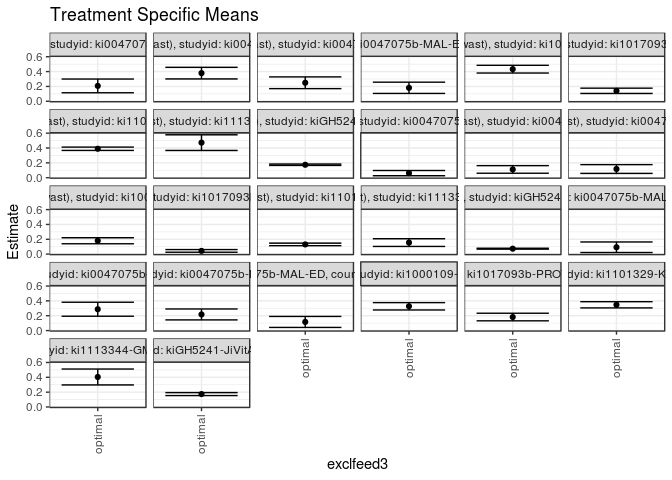

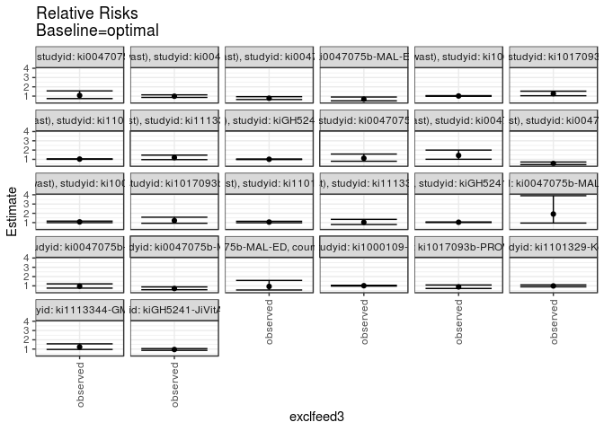

## Results Table

### Parameter: TSM

| agecat | studyid | country | intervention_level | baseline_level | estimate | ci_lower | ci_upper |
| --- | --- | --- | --- | --- | --- | --- | --- |
| 0-24 months (no birth wast) | ki0047075b-MAL-ED | BANGLADESH | optimal | NA | 0.2071149 | 0.1146855 | 0.2995442 |
| 0-24 months (no birth wast) | ki0047075b-MAL-ED | INDIA | optimal | NA | 0.3790440 | 0.3008004 | 0.4572876 |
| 0-24 months (no birth wast) | ki0047075b-MAL-ED | NEPAL | optimal | NA | 0.2491948 | 0.1703068 | 0.3280828 |
| 0-24 months (no birth wast) | ki0047075b-MAL-ED | TANZANIA, UNITED REPUBLIC OF | optimal | NA | 0.1812994 | 0.1052893 | 0.2573096 |
| 0-24 months (no birth wast) | ki1000109-EE | PAKISTAN | optimal | NA | 0.4326130 | 0.3804853 | 0.4847407 |
| 0-24 months (no birth wast) | ki1017093b-PROVIDE | BANGLADESH | optimal | NA | 0.1406156 | 0.1049084 | 0.1763228 |
| 0-24 months (no birth wast) | ki1101329-Keneba | GAMBIA | optimal | NA | 0.3897522 | 0.3670876 | 0.4124168 |
| 0-24 months (no birth wast) | ki1113344-GMS-Nepal | NEPAL | optimal | NA | 0.4724378 | 0.3668706 | 0.5780049 |
| 0-24 months (no birth wast) | kiGH5241-JiVitA-3 | BANGLADESH | optimal | NA | 0.1742656 | 0.1649988 | 0.1835325 |
| 0-6 months (no birth wast) | ki0047075b-MAL-ED | BANGLADESH | optimal | NA | 0.0615334 | 0.0262165 | 0.0968502 |
| 0-6 months (no birth wast) | ki0047075b-MAL-ED | INDIA | optimal | NA | 0.1113299 | 0.0600112 | 0.1626487 |
| 0-6 months (no birth wast) | ki0047075b-MAL-ED | NEPAL | optimal | NA | 0.1169260 | 0.0578516 | 0.1760004 |
| 0-6 months (no birth wast) | ki1000109-EE | PAKISTAN | optimal | NA | 0.1802545 | 0.1395433 | 0.2209658 |
| 0-6 months (no birth wast) | ki1017093b-PROVIDE | BANGLADESH | optimal | NA | 0.0434532 | 0.0254288 | 0.0614776 |
| 0-6 months (no birth wast) | ki1101329-Keneba | GAMBIA | optimal | NA | 0.1307137 | 0.1133013 | 0.1481261 |
| 0-6 months (no birth wast) | ki1113344-GMS-Nepal | NEPAL | optimal | NA | 0.1555064 | 0.1035359 | 0.2074770 |
| 0-6 months (no birth wast) | kiGH5241-JiVitA-3 | BANGLADESH | optimal | NA | 0.0731024 | 0.0672526 | 0.0789521 |
| 6-24 months | ki0047075b-MAL-ED | BANGLADESH | optimal | NA | 0.0926058 | 0.0213555 | 0.1638562 |
| 6-24 months | ki0047075b-MAL-ED | INDIA | optimal | NA | 0.2874101 | 0.1932617 | 0.3815584 |
| 6-24 months | ki0047075b-MAL-ED | NEPAL | optimal | NA | 0.2172489 | 0.1436955 | 0.2908023 |
| 6-24 months | ki0047075b-MAL-ED | TANZANIA, UNITED REPUBLIC OF | optimal | NA | 0.1163636 | 0.0421827 | 0.1905445 |
| 6-24 months | ki1000109-EE | PAKISTAN | optimal | NA | 0.3270792 | 0.2776103 | 0.3765480 |
| 6-24 months | ki1017093b-PROVIDE | BANGLADESH | optimal | NA | 0.1822493 | 0.1308878 | 0.2336107 |
| 6-24 months | ki1101329-Keneba | GAMBIA | optimal | NA | 0.3470783 | 0.3053994 | 0.3887571 |
| 6-24 months | ki1113344-GMS-Nepal | NEPAL | optimal | NA | 0.4042815 | 0.2971169 | 0.5114460 |
| 6-24 months | kiGH5241-JiVitA-3 | BANGLADESH | optimal | NA | 0.1739518 | 0.1541083 | 0.1937953 |

### Parameter: E(Y)

| agecat | studyid | country | intervention_level | baseline_level | estimate | ci_lower | ci_upper |
| --- | --- | --- | --- | --- | --- | --- | --- |
| 0-24 months (no birth wast) | ki0047075b-MAL-ED | BANGLADESH | observed | NA | 0.2217742 | 0.1699649 | 0.2735835 |
| 0-24 months (no birth wast) | ki0047075b-MAL-ED | INDIA | observed | NA | 0.3744681 | 0.3124566 | 0.4364796 |
| 0-24 months (no birth wast) | ki0047075b-MAL-ED | NEPAL | observed | NA | 0.1923077 | 0.1417029 | 0.2429125 |
| 0-24 months (no birth wast) | ki0047075b-MAL-ED | TANZANIA, UNITED REPUBLIC OF | observed | NA | 0.1204819 | 0.0799679 | 0.1609960 |
| 0-24 months (no birth wast) | ki1000109-EE | PAKISTAN | observed | NA | 0.4388298 | 0.3886039 | 0.4890557 |
| 0-24 months (no birth wast) | ki1017093b-PROVIDE | BANGLADESH | observed | NA | 0.1775837 | 0.1489858 | 0.2061816 |
| 0-24 months (no birth wast) | ki1101329-Keneba | GAMBIA | observed | NA | 0.4007937 | 0.3793963 | 0.4221910 |
| 0-24 months (no birth wast) | ki1113344-GMS-Nepal | NEPAL | observed | NA | 0.5622318 | 0.5171396 | 0.6073240 |
| 0-24 months (no birth wast) | kiGH5241-JiVitA-3 | BANGLADESH | observed | NA | 0.1758810 | 0.1679189 | 0.1838431 |
| 0-6 months (no birth wast) | ki0047075b-MAL-ED | BANGLADESH | observed | NA | 0.0688259 | 0.0371906 | 0.1004612 |
| 0-6 months (no birth wast) | ki0047075b-MAL-ED | INDIA | observed | NA | 0.1581197 | 0.1112720 | 0.2049674 |
| 0-6 months (no birth wast) | ki0047075b-MAL-ED | NEPAL | observed | NA | 0.0646552 | 0.0329427 | 0.0963676 |
| 0-6 months (no birth wast) | ki1000109-EE | PAKISTAN | observed | NA | 0.1935484 | 0.1533466 | 0.2337501 |
| 0-6 months (no birth wast) | ki1017093b-PROVIDE | BANGLADESH | observed | NA | 0.0527086 | 0.0359384 | 0.0694789 |
| 0-6 months (no birth wast) | ki1101329-Keneba | GAMBIA | observed | NA | 0.1380169 | 0.1229232 | 0.1531107 |
| 0-6 months (no birth wast) | ki1113344-GMS-Nepal | NEPAL | observed | NA | 0.1607143 | 0.1266675 | 0.1947611 |
| 0-6 months (no birth wast) | kiGH5241-JiVitA-3 | BANGLADESH | observed | NA | 0.0758803 | 0.0704341 | 0.0813266 |
| 6-24 months | ki0047075b-MAL-ED | BANGLADESH | observed | NA | 0.1779661 | 0.1290640 | 0.2268682 |
| 6-24 months | ki0047075b-MAL-ED | INDIA | observed | NA | 0.2746781 | 0.2172425 | 0.3321138 |
| 6-24 months | ki0047075b-MAL-ED | NEPAL | observed | NA | 0.1551724 | 0.1084814 | 0.2018634 |
| 6-24 months | ki0047075b-MAL-ED | TANZANIA, UNITED REPUBLIC OF | observed | NA | 0.1087866 | 0.0692283 | 0.1483450 |
| 6-24 months | ki1000109-EE | PAKISTAN | observed | NA | 0.3315508 | 0.2837756 | 0.3793260 |
| 6-24 months | ki1017093b-PROVIDE | BANGLADESH | observed | NA | 0.1609756 | 0.1319065 | 0.1900447 |
| 6-24 months | ki1101329-Keneba | GAMBIA | observed | NA | 0.3434555 | 0.3221539 | 0.3647571 |
| 6-24 months | ki1113344-GMS-Nepal | NEPAL | observed | NA | 0.4957265 | 0.4503800 | 0.5410730 |
| 6-24 months | kiGH5241-JiVitA-3 | BANGLADESH | observed | NA | 0.1657825 | 0.1564932 | 0.1750718 |

### Parameter: RR

| agecat | studyid | country | intervention_level | baseline_level | estimate | ci_lower | ci_upper |
| --- | --- | --- | --- | --- | --- | --- | --- |
| 0-24 months (no birth wast) | ki0047075b-MAL-ED | BANGLADESH | observed | optimal | 1.0707787 | 0.7337883 | 1.5625310 |
| 0-24 months (no birth wast) | ki0047075b-MAL-ED | INDIA | observed | optimal | 0.9879277 | 0.8587184 | 1.1365789 |
| 0-24 months (no birth wast) | ki0047075b-MAL-ED | NEPAL | observed | optimal | 0.7717162 | 0.6346785 | 0.9383426 |
| 0-24 months (no birth wast) | ki0047075b-MAL-ED | TANZANIA, UNITED REPUBLIC OF | observed | optimal | 0.6645467 | 0.4880503 | 0.9048703 |
| 0-24 months (no birth wast) | ki1000109-EE | PAKISTAN | observed | optimal | 1.0143704 | 0.9815600 | 1.0482775 |
| 0-24 months (no birth wast) | ki1017093b-PROVIDE | BANGLADESH | observed | optimal | 1.2629017 | 1.0399716 | 1.5336195 |
| 0-24 months (no birth wast) | ki1101329-Keneba | GAMBIA | observed | optimal | 1.0283294 | 1.0060642 | 1.0510873 |
| 0-24 months (no birth wast) | ki1113344-GMS-Nepal | NEPAL | observed | optimal | 1.1900653 | 0.9715339 | 1.4577519 |
| 0-24 months (no birth wast) | kiGH5241-JiVitA-3 | BANGLADESH | observed | optimal | 1.0092695 | 0.9769529 | 1.0426551 |
| 0-6 months (no birth wast) | ki0047075b-MAL-ED | BANGLADESH | observed | optimal | 1.1185136 | 0.7959349 | 1.5718280 |
| 0-6 months (no birth wast) | ki0047075b-MAL-ED | INDIA | observed | optimal | 1.4202796 | 1.0094371 | 1.9983357 |
| 0-6 months (no birth wast) | ki0047075b-MAL-ED | NEPAL | observed | optimal | 0.5529581 | 0.4277308 | 0.7148482 |
| 0-6 months (no birth wast) | ki1000109-EE | PAKISTAN | observed | optimal | 1.0737504 | 0.9919514 | 1.1622948 |
| 0-6 months (no birth wast) | ki1017093b-PROVIDE | BANGLADESH | observed | optimal | 1.2129978 | 0.9308369 | 1.5806892 |
| 0-6 months (no birth wast) | ki1101329-Keneba | GAMBIA | observed | optimal | 1.0558718 | 0.9787041 | 1.1391238 |
| 0-6 months (no birth wast) | ki1113344-GMS-Nepal | NEPAL | observed | optimal | 1.0334896 | 0.7946128 | 1.3441777 |
| 0-6 months (no birth wast) | kiGH5241-JiVitA-3 | BANGLADESH | observed | optimal | 1.0380006 | 1.0066600 | 1.0703170 |
| 6-24 months | ki0047075b-MAL-ED | BANGLADESH | observed | optimal | 1.9217595 | 0.9477847 | 3.8966232 |
| 6-24 months | ki0047075b-MAL-ED | INDIA | observed | optimal | 0.9557011 | 0.7536381 | 1.2119405 |
| 6-24 months | ki0047075b-MAL-ED | NEPAL | observed | optimal | 0.7142611 | 0.5772062 | 0.8838589 |
| 6-24 months | ki0047075b-MAL-ED | TANZANIA, UNITED REPUBLIC OF | observed | optimal | 0.9348853 | 0.5528636 | 1.5808790 |
| 6-24 months | ki1000109-EE | PAKISTAN | observed | optimal | 1.0136714 | 0.9718787 | 1.0572612 |
| 6-24 months | ki1017093b-PROVIDE | BANGLADESH | observed | optimal | 0.8832716 | 0.7162345 | 1.0892642 |
| 6-24 months | ki1101329-Keneba | GAMBIA | observed | optimal | 0.9895621 | 0.8931499 | 1.0963817 |
| 6-24 months | ki1113344-GMS-Nepal | NEPAL | observed | optimal | 1.2261915 | 0.9619863 | 1.5629594 |
| 6-24 months | kiGH5241-JiVitA-3 | BANGLADESH | observed | optimal | 0.9530370 | 0.8638380 | 1.0514467 |

### Parameter: PAR

| agecat | studyid | country | intervention_level | baseline_level | estimate | ci_lower | ci_upper |
| --- | --- | --- | --- | --- | --- | --- | --- |
| 0-24 months (no birth wast) | ki0047075b-MAL-ED | BANGLADESH | optimal | NA | 0.0146593 | -0.0636545 | 0.0929731 |
| 0-24 months (no birth wast) | ki0047075b-MAL-ED | INDIA | optimal | NA | -0.0045759 | -0.0576385 | 0.0484867 |
| 0-24 months (no birth wast) | ki0047075b-MAL-ED | NEPAL | optimal | NA | -0.0568871 | -0.1068342 | -0.0069400 |
| 0-24 months (no birth wast) | ki0047075b-MAL-ED | TANZANIA, UNITED REPUBLIC OF | optimal | NA | -0.0608175 | -0.1173059 | -0.0043291 |
| 0-24 months (no birth wast) | ki1000109-EE | PAKISTAN | optimal | NA | 0.0062168 | -0.0079934 | 0.0204271 |
| 0-24 months (no birth wast) | ki1017093b-PROVIDE | BANGLADESH | optimal | NA | 0.0369681 | 0.0090937 | 0.0648425 |
| 0-24 months (no birth wast) | ki1101329-Keneba | GAMBIA | optimal | NA | 0.0110414 | 0.0025027 | 0.0195802 |
| 0-24 months (no birth wast) | ki1113344-GMS-Nepal | NEPAL | optimal | NA | 0.0897940 | -0.0058111 | 0.1853991 |
| 0-24 months (no birth wast) | kiGH5241-JiVitA-3 | BANGLADESH | optimal | NA | 0.0016154 | -0.0040633 | 0.0072940 |
| 0-6 months (no birth wast) | ki0047075b-MAL-ED | BANGLADESH | optimal | NA | 0.0072925 | -0.0138849 | 0.0284700 |
| 0-6 months (no birth wast) | ki0047075b-MAL-ED | INDIA | optimal | NA | 0.0467897 | 0.0068514 | 0.0867281 |
| 0-6 months (no birth wast) | ki0047075b-MAL-ED | NEPAL | optimal | NA | -0.0522708 | -0.0875629 | -0.0169787 |
| 0-6 months (no birth wast) | ki1000109-EE | PAKISTAN | optimal | NA | 0.0132938 | -0.0011224 | 0.0277100 |
| 0-6 months (no birth wast) | ki1017093b-PROVIDE | BANGLADESH | optimal | NA | 0.0092554 | -0.0026081 | 0.0211189 |
| 0-6 months (no birth wast) | ki1101329-Keneba | GAMBIA | optimal | NA | 0.0073032 | -0.0026479 | 0.0172543 |
| 0-6 months (no birth wast) | ki1113344-GMS-Nepal | NEPAL | optimal | NA | 0.0052079 | -0.0357031 | 0.0461188 |
| 0-6 months (no birth wast) | kiGH5241-JiVitA-3 | BANGLADESH | optimal | NA | 0.0027779 | 0.0005420 | 0.0050139 |
| 6-24 months | ki0047075b-MAL-ED | BANGLADESH | optimal | NA | 0.0853603 | 0.0167861 | 0.1539345 |
| 6-24 months | ki0047075b-MAL-ED | INDIA | optimal | NA | -0.0127320 | -0.0812447 | 0.0557808 |
| 6-24 months | ki0047075b-MAL-ED | NEPAL | optimal | NA | -0.0620765 | -0.1090221 | -0.0151309 |
| 6-24 months | ki0047075b-MAL-ED | TANZANIA, UNITED REPUBLIC OF | optimal | NA | -0.0075770 | -0.0687534 | 0.0535995 |
| 6-24 months | ki1000109-EE | PAKISTAN | optimal | NA | 0.0044716 | -0.0092965 | 0.0182398 |
| 6-24 months | ki1017093b-PROVIDE | BANGLADESH | optimal | NA | -0.0212737 | -0.0598150 | 0.0172676 |
| 6-24 months | ki1101329-Keneba | GAMBIA | optimal | NA | -0.0036228 | -0.0392030 | 0.0319575 |
| 6-24 months | ki1113344-GMS-Nepal | NEPAL | optimal | NA | 0.0914450 | -0.0064507 | 0.1893407 |
| 6-24 months | kiGH5241-JiVitA-3 | BANGLADESH | optimal | NA | -0.0081693 | -0.0252784 | 0.0089398 |

### Parameter: PAF

| agecat | studyid | country | intervention_level | baseline_level | estimate | ci_lower | ci_upper |
| --- | --- | --- | --- | --- | --- | --- | --- |
| 0-24 months (no birth wast) | ki0047075b-MAL-ED | BANGLADESH | optimal | NA | 0.0661002 | -0.3627908 | 0.3600127 |
| 0-24 months (no birth wast) | ki0047075b-MAL-ED | INDIA | optimal | NA | -0.0122198 | -0.1645261 | 0.1201666 |
| 0-24 months (no birth wast) | ki0047075b-MAL-ED | NEPAL | optimal | NA | -0.2958131 | -0.5756008 | -0.0657088 |
| 0-24 months (no birth wast) | ki0047075b-MAL-ED | TANZANIA, UNITED REPUBLIC OF | optimal | NA | -0.5047852 | -1.0489690 | -0.1051307 |
| 0-24 months (no birth wast) | ki1000109-EE | PAKISTAN | optimal | NA | 0.0141668 | -0.0187864 | 0.0460542 |
| 0-24 months (no birth wast) | ki1017093b-PROVIDE | BANGLADESH | optimal | NA | 0.2081727 | 0.0384352 | 0.3479478 |
| 0-24 months (no birth wast) | ki1101329-Keneba | GAMBIA | optimal | NA | 0.0275489 | 0.0060277 | 0.0486042 |
| 0-24 months (no birth wast) | ki1113344-GMS-Nepal | NEPAL | optimal | NA | 0.1597099 | -0.0293002 | 0.3140122 |
| 0-24 months (no birth wast) | kiGH5241-JiVitA-3 | BANGLADESH | optimal | NA | 0.0091844 | -0.0235908 | 0.0409101 |
| 0-6 months (no birth wast) | ki0047075b-MAL-ED | BANGLADESH | optimal | NA | 0.1059564 | -0.2563842 | 0.3637981 |
| 0-6 months (no birth wast) | ki0047075b-MAL-ED | INDIA | optimal | NA | 0.2959133 | 0.0093489 | 0.4995836 |
| 0-6 months (no birth wast) | ki0047075b-MAL-ED | NEPAL | optimal | NA | -0.8084554 | -1.3379189 | -0.3988984 |
| 0-6 months (no birth wast) | ki1000109-EE | PAKISTAN | optimal | NA | 0.0686849 | -0.0081139 | 0.1396331 |
| 0-6 months (no birth wast) | ki1017093b-PROVIDE | BANGLADESH | optimal | NA | 0.1755962 | -0.0743021 | 0.3673646 |
| 0-6 months (no birth wast) | ki1101329-Keneba | GAMBIA | optimal | NA | 0.0529153 | -0.0217593 | 0.1221323 |
| 0-6 months (no birth wast) | ki1113344-GMS-Nepal | NEPAL | optimal | NA | 0.0324044 | -0.2584746 | 0.2560508 |
| 0-6 months (no birth wast) | kiGH5241-JiVitA-3 | BANGLADESH | optimal | NA | 0.0366094 | 0.0066159 | 0.0656973 |
| 6-24 months | ki0047075b-MAL-ED | BANGLADESH | optimal | NA | 0.4796435 | -0.0550920 | 0.7433675 |
| 6-24 months | ki0047075b-MAL-ED | INDIA | optimal | NA | -0.0463523 | -0.3268969 | 0.1748770 |
| 6-24 months | ki0047075b-MAL-ED | NEPAL | optimal | NA | -0.4000483 | -0.7324831 | -0.1314023 |
| 6-24 months | ki0047075b-MAL-ED | TANZANIA, UNITED REPUBLIC OF | optimal | NA | -0.0696500 | -0.8087644 | 0.3674405 |
| 6-24 months | ki1000109-EE | PAKISTAN | optimal | NA | 0.0134870 | -0.0289350 | 0.0541600 |
| 6-24 months | ki1017093b-PROVIDE | BANGLADESH | optimal | NA | -0.1321546 | -0.3961907 | 0.0819491 |
| 6-24 months | ki1101329-Keneba | GAMBIA | optimal | NA | -0.0105480 | -0.1196329 | 0.0879089 |
| 6-24 months | ki1113344-GMS-Nepal | NEPAL | optimal | NA | 0.1844667 | -0.0395158 | 0.3601881 |
| 6-24 months | kiGH5241-JiVitA-3 | BANGLADESH | optimal | NA | -0.0492772 | -0.1576245 | 0.0489295 |